# Early migration phenology models

As a reminder, the figure below displays a mile-high view of migration timing across different striped bass spawning groups: Hudson River (HR), Delaware River (DE), and Potomac River (PR). The length of the line displays the range of residence of each group in either the natal estuary (colors) or coastal Massachusetts (yellow). The circle shows the median day of arrival in the given array, and the triangle shows the median date of departure. Only fish that were larger than 800 mm at the time of tagging are shown.

[output not shown]

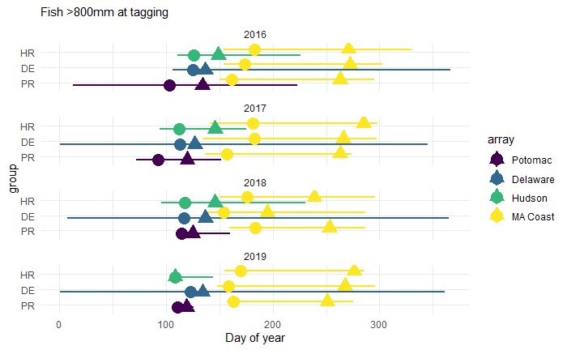

I’m going to make a quick-and-dirty model to compare the timing of entry into coastal Massachusetts by spawning group. The full model includes day of year (“yday”, numeric), spawning group (“group”, factor), the year (“year”, ordered factor), and all interactions.

The response was modeled as binomial, with the cumulative number of fish that have entered Massachusetts waters per group-year combination considered “successes” and the total number of fish that arrived in coastal MA per group-year combination as the number of trials.

Using step-wise variable selection…

```
Start:  AIC=876.21
cbind(success, trials - success) ~ 0 + group + yday + year +
    group:yday + group:year + year:yday + group:year:yday

                  Df Deviance    AIC
<none>                 204.73 876.21
- group:yday:year  6   220.74 880.23
```

…the variables selected are: group, yday, year, group:yday, group:year, yday:year, group:yday:year.

```
Call:
glm(formula = cbind(success, trials - success) ~ 0 + group +
    yday + year + group:yday + group:year + year:yday + group:year:yday,
    family = "binomial", data = binom_data[array == "MA Coast"])

Deviance Residuals:
    Min       1Q   Median       3Q      Max
-3.9854  -0.6261   0.0378   0.4881   2.1411

Coefficients:
                      Estimate Std. Error z value Pr(>|z|)
groupDE             -15.875824   1.328794 -11.948  < 2e-16 ***
groupHR             -11.264119   1.173194  -9.601  < 2e-16 ***
groupPR             -18.541642   2.964276  -6.255 3.97e-10 ***
yday                  0.097072   0.008390  11.570  < 2e-16 ***
year.L               -8.841642   2.298368  -3.847  0.00012 ***
year.Q               -4.173475   2.657588  -1.570  0.11632
year.C                4.614116   2.973727   1.552  0.12075
groupHR:yday         -0.033435   0.010911  -3.064  0.00218 **
groupPR:yday          0.014470   0.019871   0.728  0.46650
groupHR:year.L        8.480084   3.853682   2.201  0.02777 *
groupPR:year.L        9.320778   7.243423   1.287  0.19817
groupHR:year.Q       -2.710364   3.545181  -0.765  0.44456
groupPR:year.Q        0.729079   6.496961   0.112  0.91065
groupHR:year.C       -4.344584   3.207141  -1.355  0.17553
groupPR:year.C        4.656374   5.652772   0.824  0.41009
yday:year.L           0.061693   0.014208   4.342 1.41e-05 ***
yday:year.Q           0.023110   0.016779   1.377  0.16842
yday:year.C          -0.033881   0.019006  -1.783  0.07464 .
groupHR:yday:year.L  -0.055324   0.023270  -2.377  0.01743 *
groupPR:yday:year.L  -0.072239   0.044520  -1.623  0.10467
groupHR:yday:year.Q   0.018236   0.021822   0.836  0.40333
groupPR:yday:year.Q   0.002267   0.039743   0.057  0.95451
groupHR:yday:year.C   0.033170   0.020270   1.636  0.10177
groupPR:yday:year.C  -0.013135   0.034307  -0.383  0.70181
---
Signif. codes:  0 ‘***’ 0.001 ‘**’ 0.01 ‘*’ 0.05 ‘.’ 0.1 ‘ ’ 1

(Dispersion parameter for binomial family taken to be 1)

    Null deviance: 2656.34  on 202  degrees of freedom
Residual deviance:  204.73  on 178  degrees of freedom
AIC: 876.21

Number of Fisher Scoring iterations: 5
```

When looking at pairwise contrasts by year, the only significant differences occur in 2018, where arrival in MA was more rapid in DE and PR fish when compared to HR fish (greater yday slope).

```
year = 2016:
 contrast estimate      SE  df z.ratio p.value
 DE - HR  -0.00538 0.00971 Inf  -0.554  0.8443
 DE - PR  -0.06700 0.05253 Inf  -1.275  0.4091
 HR - PR  -0.06162 0.05187 Inf  -1.188  0.4604

year = 2017:
 contrast estimate      SE  df z.ratio p.value
 DE - HR   0.00793 0.00513 Inf   1.547  0.2691
 DE - PR  -0.02068 0.02399 Inf  -0.862  0.6644
 HR - PR  -0.02861 0.02372 Inf  -1.206  0.4494

year = 2018:
 contrast estimate      SE  df z.ratio p.value
 DE - HR   0.07717 0.02762 Inf   2.794  0.0144
 DE - PR  -0.00599 0.03971 Inf  -0.151  0.9875
 HR - PR  -0.08317 0.02924 Inf  -2.845  0.0124

year = 2019:
 contrast estimate      SE  df z.ratio p.value
 DE - HR   0.05401 0.03196 Inf   1.690  0.2090
 DE - PR   0.03579 0.03750 Inf   0.955  0.6056
 HR - PR  -0.01822 0.04316 Inf  -0.422  0.9064

P value adjustment: tukey method for comparing a family of 3 estimates
```

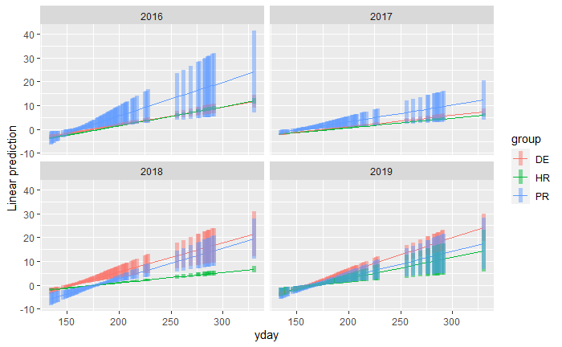

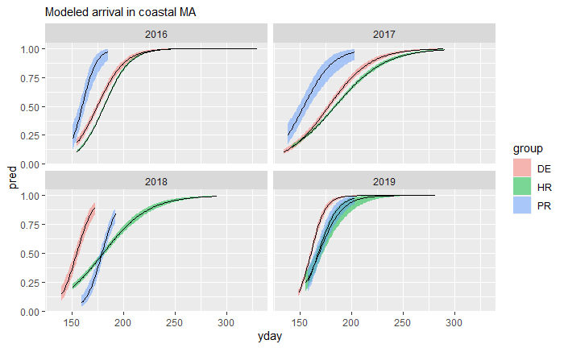